# Thoughts on independent variables

- cétacés observés
- nombre de groupes observés
- taille moyenne des groupes
- espèce principal

and we have two contributing variables:

- état de mer
- effort d’échantillonage

this file is going to try and understand the relationship between these variables and how to best conceptualize our target variables.

```r
suppressPackageStartupMessages({
  library(ggplot2)
  library(tidyverse)
  library(viridis)
  library(ggpubr)
  library(rstatix)
})

cetaces <- read.table("../jeux_de_donnees/Cetaces_Transects.csv", header = TRUE, sep = ";", dec = ".", comment.char = "#") |>
  mutate(across(c(secteur, saison, etat_mer_beaufort), as.factor),
         presence = presence == 1)
```

# Effects of Confounding variables

## Effet of effort d’échantillonage

### Presence vs. Sampling Effort

It seems likely that there is a significant effect of sampling effort on observed cétacés and/or number of groups observed.

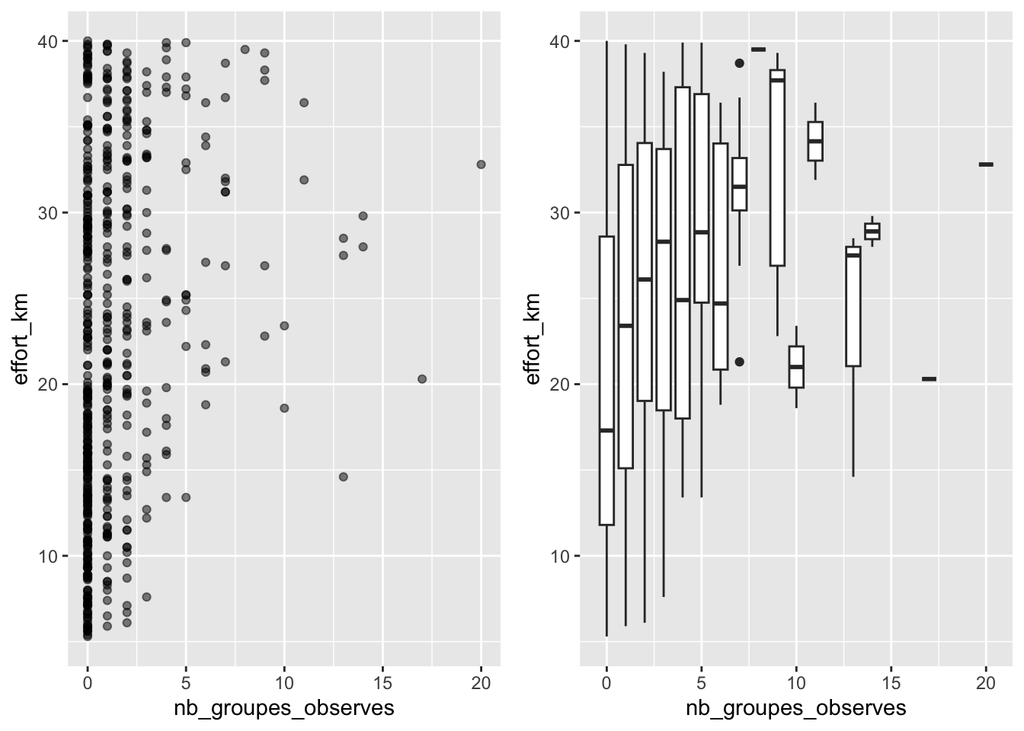

```r
pbox <- ggplot(cetaces, aes(x=nb_groupes_observes, y=effort_km, group = nb_groupes_observes)) +
  geom_boxplot()
pscatter <- ggplot(cetaces, aes(x=nb_groupes_observes, y=effort_km)) +
  geom_point(alpha = 0.5)

ggarrange(pscatter, pbox, ncol=2)
```

To start, is there a significant difference in effort_km between presence and absence ?

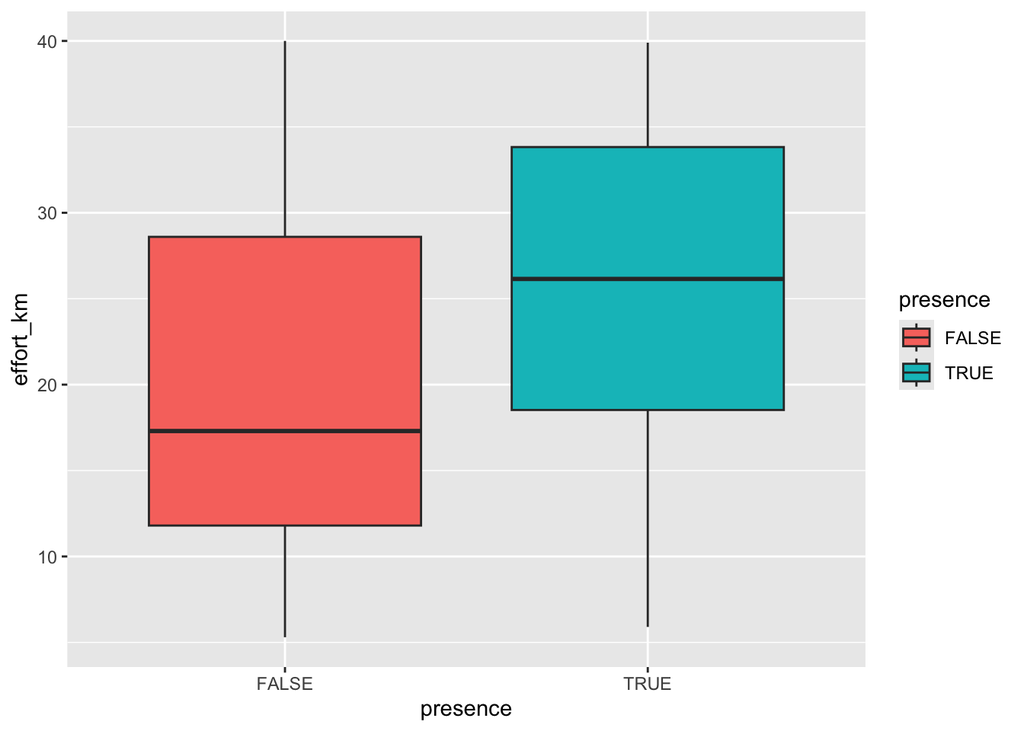

```r
ggplot(cetaces, aes(x = presence, y = effort_km, fill = presence, group = presence)) + geom_boxplot()
```

```r
# Get the same stats represented by the boxplot
# cetaces |>
#   group_by(presence) |>
#   summarize(mean = mean(effort_km), sd = sd(effort_km))

# ANOVA: means of effort_km are significantly different between presence = TRUE and presence = FALSE
pa_vs_effort <- aov(effort_km ~ presence, data = cetaces)

# Verify conditions of application
# Homoscedascity of residuals : ACCEPTS
bartlett.test(residuals(pa_vs_effort) ~ presence, data = cetaces)
```

```
##
##  Bartlett test of homogeneity of variances
##
## data:  residuals(pa_vs_effort) by presence
## Bartlett's K-squared = 0.85633, df = 1, p-value = 0.3548
```

```r
library(DescTools)
# LeveneTest(effort_km ~ presence, data = cetaces, center = median)
# Normality of residuals : REJECTS, however the shapiro test is known to be overly sensitive to sample sizes over a couple hundred
shapiro.test(residuals(pa_vs_effort))
```

```
##
##  Shapiro-Wilk normality test
##
## data:  residuals(pa_vs_effort)
## W = 0.96987, p-value = 4.356e-09
```

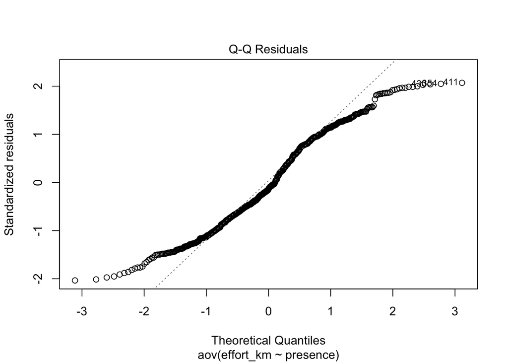

```r
# Do another check here…
plot(pa_vs_effort, which = 2)
```

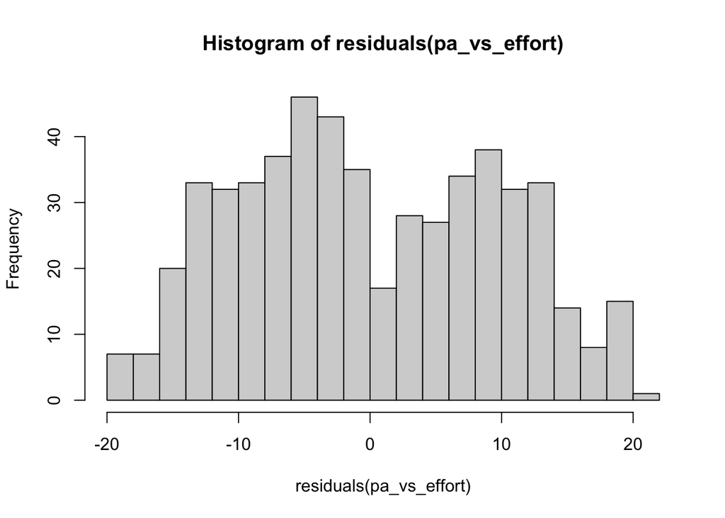

```r
hist(residuals(pa_vs_effort), breaks = 20)
```

Normality of residus isn’t respected since the QQplot is lightly tailed. Given the large size of the dataset ANOVA is probably robust enough so that it doesnt matter, but to be safe we’ll instead proceed with a Welch test.

```r
t.test(effort_km ~ presence, data = cetaces, var.equal = FALSE)
```

```
##
##  Welch Two Sample t-test
##
## data:  effort_km by presence
## t = -6.7954, df = 536.29, p-value = 2.881e-11
## alternative hypothesis: true difference in means between group FALSE and group TRUE is not equal to 0
## 95 percent confidence interval:
##  -7.319567 -4.036729
## sample estimates:
## mean in group FALSE  mean in group TRUE
##            19.94296            25.62111
```

Thus we can conclude that effort_km is significantly different between presence = TRUE and presence = FALSE.

### Number of groupes vs. Sampling Effort

Now let’s take a look at this at the level of the actual number of groups observed. My hypothesis is that there’s a linear relationship.

```r
count(cetaces, nb_groupes_observes)
```

```
##    nb_groupes_observes   n
## 1                    0 270
## 2                    1 108
## 3                    2  72
## 4                    3  28
## 5                    4  17
## 6                    5  12
## 7                    6   8
## 8                    7   8
## 9                    8   1
## 10                   9   5
## 11                  10   2
## 12                  11   2
## 13                  13   3
## 14                  14   2
## 15                  17   1
## 16                  20   1
```

To note, some of the effectifs are 1 here. If we wanted to use ANOVA, while it is robust to different effectifs the small sizes would negatively impact variance. Might be worth thinking about reclassification.

For the moment, since we’re working with a count variable we’ll start with a Poisson regression.

```r
res <- glm(nb_groupes_observes ~ effort_km, data = cetaces |> filter(presence), family = poisson(link = "log"))

summary(res)
```

```
##
## Call:
## glm(formula = nb_groupes_observes ~ effort_km, family = poisson(link = "log"),
##     data = filter(cetaces, presence))
##
## Coefficients:
##             Estimate Std. Error z value Pr(>|z|)
## (Intercept) 0.595155   0.112814   5.276 1.32e-07 ***
## effort_km   0.017028   0.003945   4.316 1.59e-05 ***
## ---
## Signif. codes:  0 '***' 0.001 '**' 0.01 '*' 0.05 '.' 0.1 ' ' 1
##
## (Dispersion parameter for poisson family taken to be 1)
##
##     Null deviance: 546.86  on 269  degrees of freedom
## Residual deviance: 527.83  on 268  degrees of freedom
## AIC: 1249.6
##
## Number of Fisher Scoring iterations: 5
```

```r
deviance(res) / df.residual(res)
```

```
## [1] 1.969527
```

Since there is significant overdispersion, the Poisson regression here isn’t suitable (assumes variance(Y) = mean(Y). Let’s try the negative binomial… [link](https://utstat.utoronto.ca/reid/sta2201s/QUASI-POISSON.pdf)

```r
res <- MASS::glm.nb(nb_groupes_observes ~ effort_km, data = cetaces |> filter(presence))

summary(res)
```

```
##
## Call:
## MASS::glm.nb(formula = nb_groupes_observes ~ effort_km, data = filter(cetaces,
##     presence), init.theta = 2.894378748, link = log)
##
## Coefficients:
##             Estimate Std. Error z value Pr(>|z|)
## (Intercept) 0.568845   0.154025   3.693 0.000221 ***
## effort_km   0.018026   0.005499   3.278 0.001046 **
## ---
## Signif. codes:  0 '***' 0.001 '**' 0.01 '*' 0.05 '.' 0.1 ' ' 1
##
## (Dispersion parameter for Negative Binomial(2.8944) family taken to be 1)
##
##     Null deviance: 247.86  on 269  degrees of freedom
## Residual deviance: 237.62  on 268  degrees of freedom
## AIC: 1130.4
##
## Number of Fisher Scoring iterations: 1
##
##
##               Theta:  2.894
##           Std. Err.:  0.452
##
##  2 x log-likelihood:  -1124.389
```

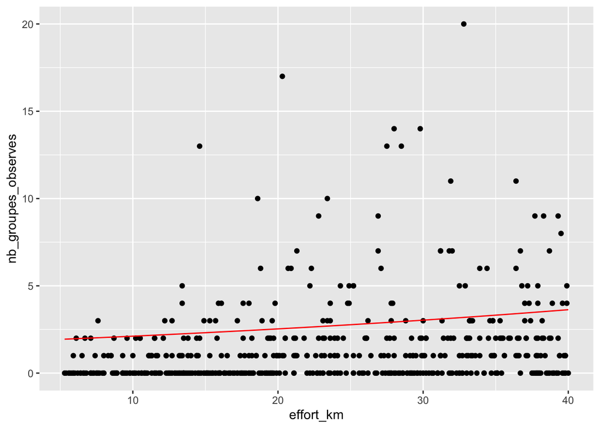

```r
plottable_res <- data.frame(effort_km = seq(from=min(cetaces$effort_km), to=max(cetaces$effort_km), length.out = 100))
plottable_res$predicted <- predict(res, plottable_res, type = "response")

ggplot(cetaces, aes(x = effort_km, y = nb_groupes_observes)) +
  geom_point() +
  geom_line(data = plottable_res, aes(x = effort_km, y = predicted), col = "red")
```

Looks like the GLM can’t really say much of anything. Let’s instead return to the reclassification & run an ANOVA to see if effort_km varies significantly between size classes.

For post-hoc with Welch I’m using (Games Howell)[https://statisticsbyjim.com/anova/welchs-anova-compared-to-classic-one-way-anova/]

```r
cetaces <- cetaces |>
  mutate(amt_groupes = cut(nb_groupes_observes,
                           breaks = c(-1, 0, 2, 5, 10, 20),
                           labels = c("0", "1-2", "3-5", "6-10", "11+")))

count(cetaces, amt_groupes)
```

```
##   amt_groupes   n
## 1           0 270
## 2         1-2 180
## 3         3-5  57
## 4        6-10  24
## 5         11+   9
```

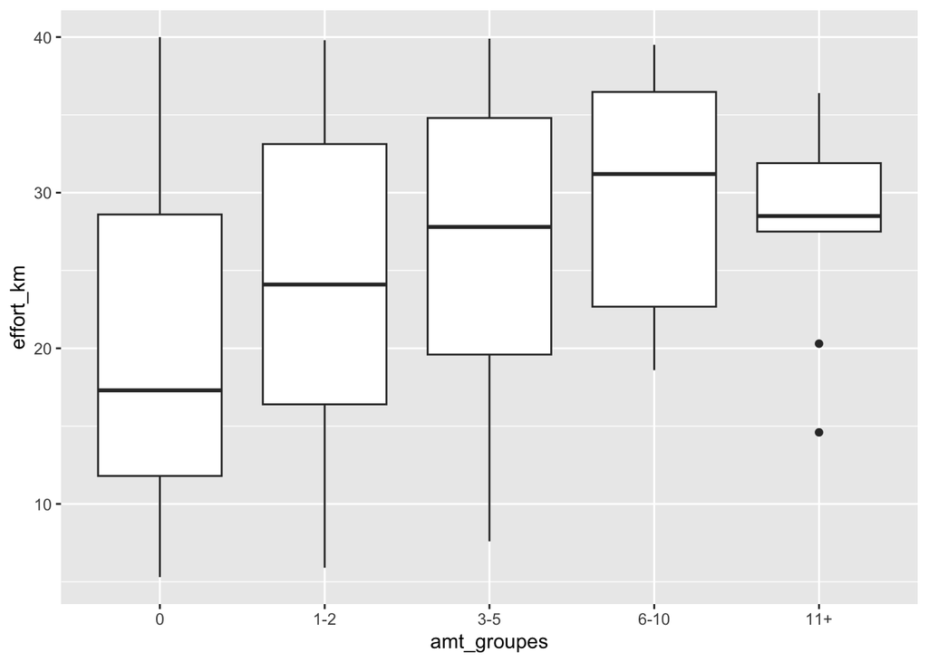

```r
ggplot(cetaces, aes(x=amt_groupes, y=effort_km, group = amt_groupes)) +
  geom_boxplot()
```

```r
# Traditional anova doesn't meet the condition of normality of residuals for the same reasons as the effort_km~presence
oneway.test(effort_km~amt_groupes, data= cetaces, var.equal=FALSE)
```

```
##
##  One-way analysis of means (not assuming equal variances)
##
## data:  effort_km and amt_groupes
## F = 15.895, num df = 4.000, denom df = 46.748, p-value = 2.778e-08
```

```r
# Do pairwise comparisons using the Wilcox Test and Holm Correction
games_howell_test(
  cetaces,
  effort_km ~ amt_groupes
)
```

```
## # A tibble: 10 × 8
##    .y.       group1 group2 estimate conf.low conf.high      p.adj p.adj.signif
##  * <chr>     <chr>  <chr>     <dbl>    <dbl>     <dbl>      <dbl> <chr>
##  1 effort_km 0      1-2       4.56     1.96       7.16 0.0000216  ****
##  2 effort_km 0      3-5       7.19     3.48      10.9  0.00000551 ****
##  3 effort_km 0      6-10      9.67     5.08      14.3  0.00000855 ****
##  4 effort_km 0      11+       7.81     0.159     15.5  0.0451     *
##  5 effort_km 1-2    3-5       2.62    -1.24       6.49 0.331      ns
##  6 effort_km 1-2    6-10      5.11     0.402      9.82 0.0278     *
##  7 effort_km 1-2    11+       3.25    -4.42      10.9  0.642      ns
##  8 effort_km 3-5    6-10      2.49    -2.84       7.81 0.681      ns
##  9 effort_km 3-5    11+       0.627   -7.25       8.51 0.999      ns
## 10 effort_km 6-10   11+      -1.86   -10.0        6.29 0.953      ns
```

All groups except are significantly different than no observation. There is a small difference between 1-2 and 6-10. While the plot seems to suggest a correlation between more individuals observed and increased effort, we can’t say much more than that effort_km is significantly higher for those samples with higher effort_km.

# Relationship between mesured values

## Relation between num groups & average size

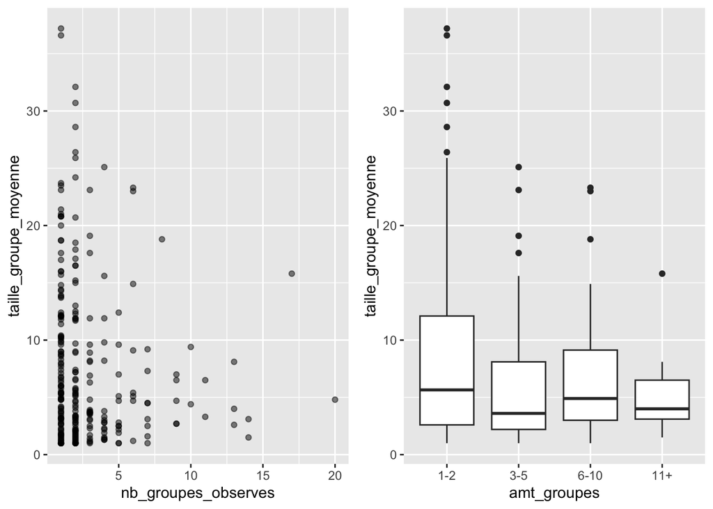

```r
cetaces_observed <- cetaces |> filter(presence)

# Plots
pscatter <- ggplot(cetaces_observed, aes(x=nb_groupes_observes, y = taille_groupe_moyenne)) +
  geom_point(alpha = 0.5)
pbox <- ggplot(cetaces_observed, aes(x = amt_groupes, y = taille_groupe_moyenne, group = amt_groupes)) +
  geom_boxplot()
ggarrange(pscatter, pbox, ncol=2)
```

```r
# ANOVA?
test <- aov(taille_groupe_moyenne ~ amt_groupes, data = cetaces_observed)
# Homogeneity fails
bartlett.test(residuals(test) ~ amt_groupes, data = cetaces_observed)
```

```
##
##  Bartlett test of homogeneity of variances
##
## data:  residuals(test) by amt_groupes
## Bartlett's K-squared = 10.595, df = 3, p-value = 0.01413
```

```r
# Normality fails
shapiro.test(residuals(test))
```

```
##
##  Shapiro-Wilk normality test
##
## data:  residuals(test)
## W = 0.85107, p-value = 1.978e-15
```

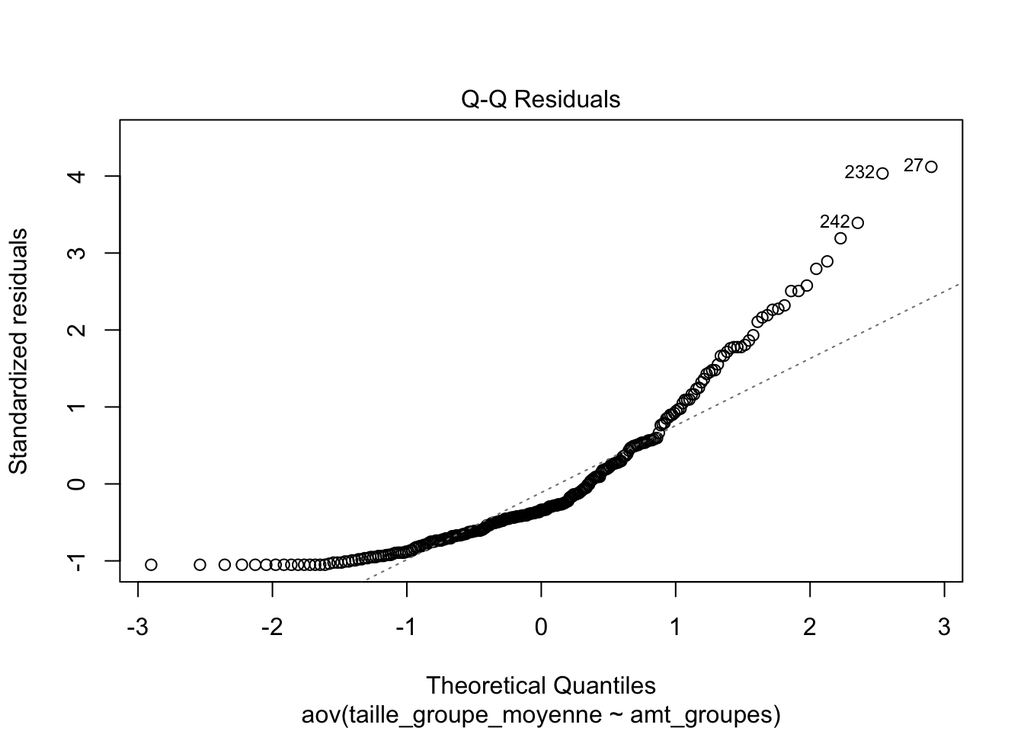

```r
# QQ plot shows strong tail
plot(test, which = 2)
```

```r
# Instead proceed with Welch
oneway.test(taille_groupe_moyenne~amt_groupes, data= cetaces_observed, var.equal=FALSE)
```

```
##
##  One-way analysis of means (not assuming equal variances)
##
## data:  taille_groupe_moyenne and amt_groupes
## F = 3.1982, num df = 3.000, denom df = 33.009, p-value = 0.03598
```

```r
# Significant result ! at least one group is different from the others…
pairwise.wilcox.test(
  cetaces_observed$taille_groupe_moyenne,
  cetaces_observed$amt_groupes,
  p.adjust.method = "holm",
  exact = FALSE
)
```

```
##
##  Pairwise comparisons using Wilcoxon rank sum test with continuity correction
##
## data:  cetaces_observed$taille_groupe_moyenne and cetaces_observed$amt_groupes
##
##      1-2  3-5  6-10
## 3-5  0.11 -    -
## 6-10 1.00 0.57 -
## 11+  1.00 1.00 1.00
##
## P value adjustment method: holm
```

```r
games_howell_test(
  cetaces_observed,
  taille_groupe_moyenne ~ amt_groupes
)
```

```
## # A tibble: 6 × 8
##   .y.              group1 group2 estimate conf.low conf.high  p.adj p.adj.signif
## * <chr>            <chr>  <chr>     <dbl>    <dbl>     <dbl>  <dbl> <chr>
## 1 taille_groupe_m… 1-2    3-5      -2.70     -5.11    -0.293 0.0213 *
## 2 taille_groupe_m… 1-2    6-10     -0.997    -4.85     2.86  0.896  ns
## 3 taille_groupe_m… 1-2    11+      -2.83     -7.55     1.88  0.317  ns
## 4 taille_groupe_m… 3-5    6-10      1.71     -2.32     5.73  0.668  ns
## 5 taille_groupe_m… 3-5    11+      -0.130    -4.93     4.67  1.000  ns
## 6 taille_groupe_m… 6-10   11+      -1.84     -7.27     3.60  0.784  ns
```

These results show that there’s a significant difference between the number of groupes observed on a transect vs the average size of the group, but the pairwise tests than go on to show that this is only significantly different between 1-2 and 3-5. I would be cautious here and say that there isn’t really a relation.

Just out of curiosity lets map out the top 10% for each type

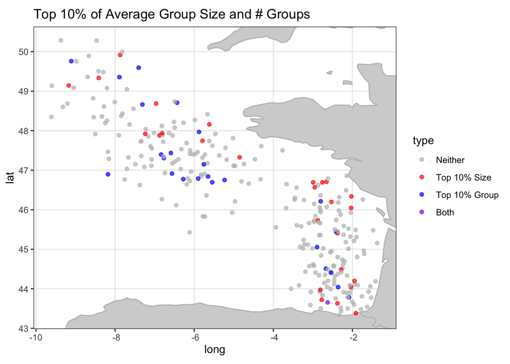

```r
color_levels = c("Neither", "Top 10% Size", "Top 10% Group", "Both")

top10s <- cetaces_observed |>
  mutate(top_10p_taille = quantile(taille_groupe_moyenne, 0.9) < taille_groupe_moyenne,
         top_10p_groupes = quantile(nb_groupes_observes, 0.9) < nb_groupes_observes,
         type = paste(top_10p_groupes, top_10p_taille) |> recode_values(
           from = c("FALSE FALSE", "FALSE TRUE", "TRUE FALSE", "TRUE TRUE"),
           to = color_levels
         ) |> factor(levels = color_levels))

xybounds <- list(
  "x" = c(min(cetaces$lon), max(cetaces$lon)),
  "y" = c(min(cetaces$lat), max(cetaces$lat))
)

ggplot(top10s, aes(lon, lat, col = type)) +
  geom_polygon(data = map_data("world"), aes(long, lat, group = group), fill = "lightgray", col = "gray") +
  geom_point(alpha = 0.7) +
  scale_color_manual(values = c("grey", "red", "blue", "purple")) +
  coord_sf(xlim = xybounds$x, ylim = xybounds$y, expand = TRUE) +
  theme_bw() +
  labs(title = "Top 10% of Average Group Size and # Groups")
```